# Biomedical Data Science School

## Day 2 Part 2: RRBS-Data

Edinburgh, MRC Institute of Genetics and Molecular Medicine Tuesday, 12th March

If you haven’t installed the packages that we need to run this tutorial you will need to do so now.

```r
if (!requireNamespace("BiocManager", quietly = TRUE))
    install.packages("BiocManager")
BiocManager::install("knitr")
BiocManager::install('TxDb.Mmusculus.UCSC.mm10.knownGene')
BiocManager::install('methylKit')
BiocManager::install('genomation')
BiocManager::install('ggplot2')
BiocManager::install("AnnotationHub")
BiocManager::install("annotatr")
BiocManager::install("bsseq")
BiocManager::install("DSS")
```

Check that all packages can be loaded:

Documentation packages:

```r
library("knitr")
```

Analysis packages:

```r
library("methylKit")
library("bsseq")
library("DSS")
```

Annotation packages:

```r
library('TxDb.Mmusculus.UCSC.mm10.knownGene')
library("AnnotationHub")
library("annotatr")
library("genomation")
```

Visualisation packages:

```r
library("ggplot2")
```

## RRBS Single CpG Analysis using methylKit

### Loading the data into R

We will start with an analysis of a small data set comprising 4 samples, two control samples and two tumor samples. The aim is to find methylation differences. I’m providing the coverage files which are outputs from `Bismark methylation extractor tool (v0.18.1)` filtered for chromosome 11. The .cov files contain the following information: chromosome, start position, end position, methylation percentage, count methylated, count unmethylated.

For example:

```bash
head Data/RRBS/chr11.RRBS_B372.cov
```

```
## chr11    3124113 3124113 0   0   6
## chr11    3124138 3124138 0   0   6
## chr11    3124161 3124161 0   0   5
## chr11    3124658 3124658 100 8   0
## chr11    3124664 3124664 0   0   8
## chr11    3126034 3126034 100 10  0
## chr11    3127214 3127214 92.511013215859 210 17
## chr11    3136007 3136007 100 10  0
## chr11    3139661 3139661 100 6   0
## chr11    3139704 3139704 100 6   0
```

To read the data into R we will first use the `MethylKit` package:

```r
file.list <- list("Data/RRBS/chr11.RRBS_B372.cov",
                  "Data/RRBS/chr11.RRBS_B436.cov",
                  "Data/RRBS/chr11.RRBS_B098.cov",
                  "Data/RRBS/chr11.RRBS_B371.cov")

    sample.ids = list("Control.1", "Control.2","Tumor1","Tumor2")
    treatment = c(0,0,1,1)

    myobj=methRead(file.list,
        sample.id=sample.ids,
        assembly="m10",
        treatment=treatment,
        context="CpG",
        pipeline="bismarkCoverage")
```

Let’s have a first look:

```r
myobj
```

```
## methylRawList object with 4 methylRaw objects
##
## methylRaw object with 60411 rows
## --------------
##     chr   start     end strand coverage numCs numTs
## 1 chr11 3126034 3126034      *       10    10     0
## 2 chr11 3127214 3127214      *      227   210    17
## 3 chr11 3136007 3136007      *       10    10     0
## 4 chr11 3148861 3148861      *       36    35     1
## 5 chr11 3149957 3149957      *       11    11     0
## 6 chr11 3149968 3149968      *       11    11     0
## --------------
## sample.id: Control.1
## assembly: m10
## context: CpG
## resolution: base
##
## methylRaw object with 44928 rows
## --------------
##     chr   start     end strand coverage numCs numTs
## 1 chr11 3124113 3124113      *       11     0    11
## 2 chr11 3124138 3124138      *       11     0    11
## 3 chr11 3124161 3124161      *       11     0    11
## 4 chr11 3124435 3124435      *       14     0    14
## 5 chr11 3124460 3124460      *       14     0    14
## 6 chr11 3127214 3127214      *      288   273    15
## --------------
## sample.id: Control.2
## assembly: m10
## context: CpG
## resolution: base
##
## methylRaw object with 79809 rows
## --------------
##     chr   start     end strand coverage numCs numTs
## 1 chr11 3105932 3105932      *       13     0    13
## 2 chr11 3106055 3106055      *       10     0    10
## 3 chr11 3111546 3111546      *       14    14     0
## 4 chr11 3111583 3111583      *       14    10     4
## 5 chr11 3118934 3118934      *       11    11     0
```

[output cut: 8 more lines]

```
## --------------
##     chr   start     end strand coverage numCs numTs
## 1 chr11 3124841 3124841      *       11     0    11
## 2 chr11 3124845 3124845      *       11    11     0
## 3 chr11 3124873 3124873      *       11     0    11
## 4 chr11 3125331 3125331      *       10    10     0
## 5 chr11 3125341 3125341      *       10    10     0
## 6 chr11 3125345 3125345      *       10     3     7
## --------------
## sample.id: Tumor2
## assembly: m10
## context: CpG
## resolution: base
##
## treatment: 0 0 1 1
```

Let’s look at the coverage of the CpG sites on the first sample:

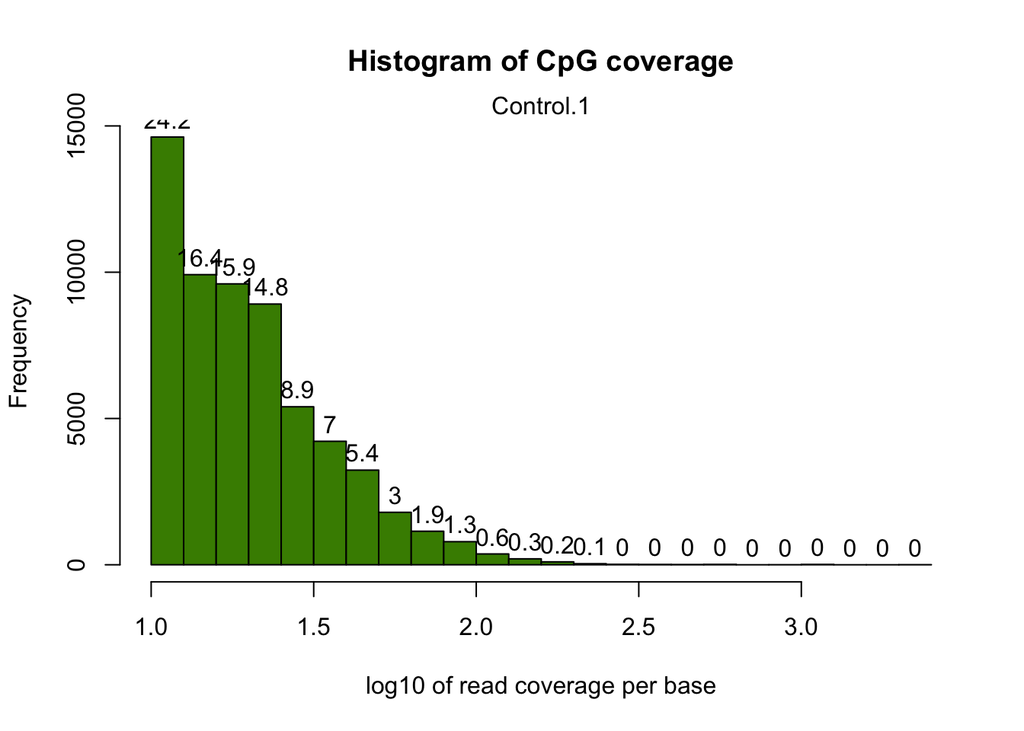

```r
getCoverageStats(myobj[[1]],plot=TRUE,both.strands=FALSE)
```

And the methylation levels:

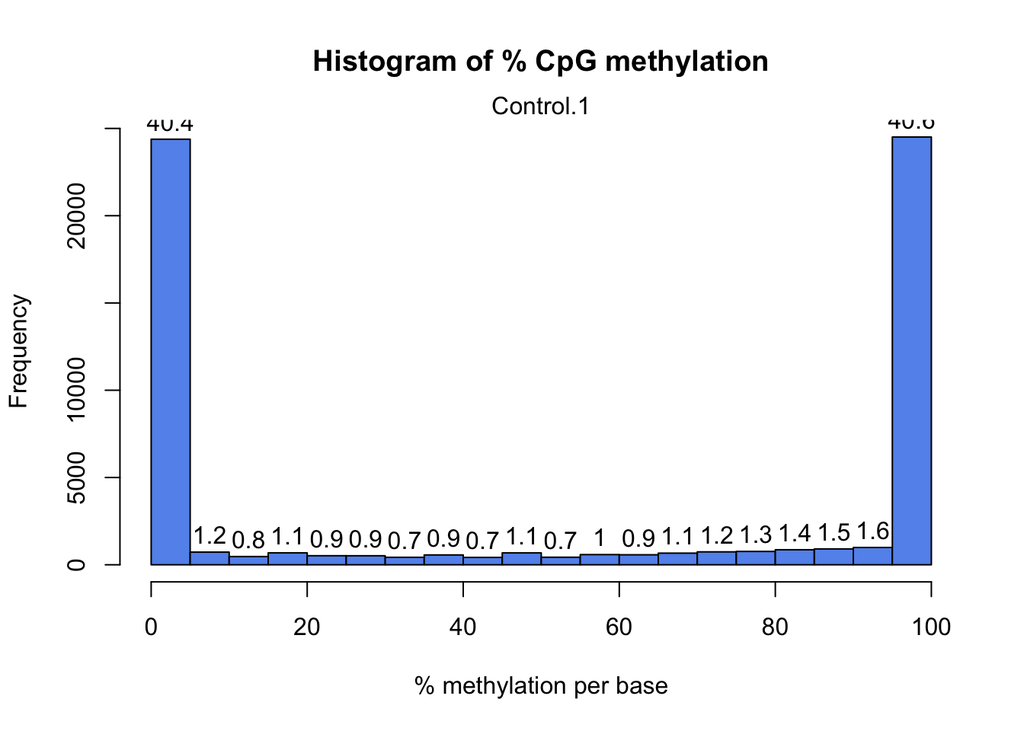

```r
getMethylationStats(myobj[[1]],plot=TRUE,both.strands=FALSE)
```

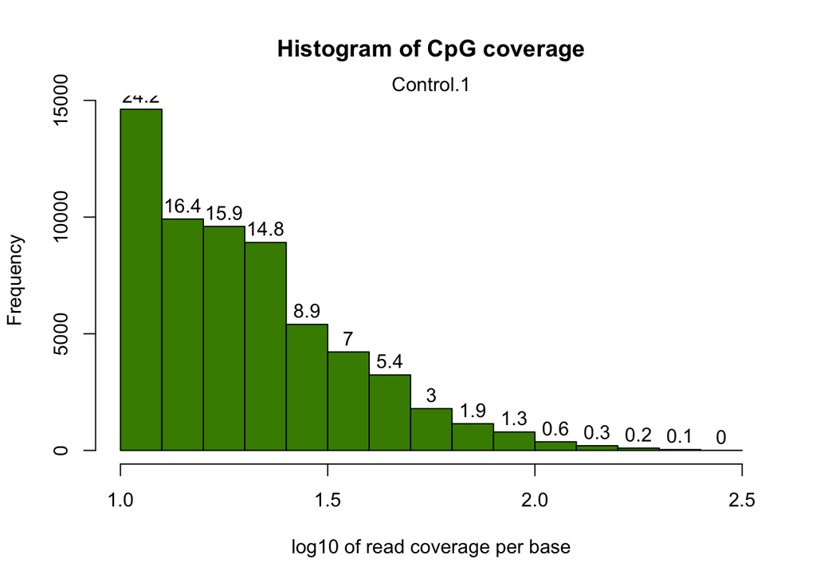

```r
filtered.myobj = filterByCoverage(myobj,lo.count=10,lo.perc=NULL,
                                      hi.count=NULL,hi.perc=99.9)
getCoverageStats(filtered.myobj[[1]],plot=TRUE,both.strands=FALSE)
```

In the next step we combine the different samples into a single table:

```r
meth = unite(filtered.myobj, destrand=FALSE)
nrow(meth)
```

```
## [1] 19113
```

```r
head(meth)
```

```
##     chr   start     end strand coverage1 numCs1 numTs1 coverage2 numCs2
## 1 chr11 3148861 3148861      *        36     35      1        25     25
## 2 chr11 3149957 3149957      *        11     11      0        16     16
## 3 chr11 3149968 3149968      *        11     11      0        16     16
## 4 chr11 3150593 3150593      *        75     75      0        35     35
## 5 chr11 3150601 3150601      *        75     64     11        35     35
## 6 chr11 3150641 3150641      *        75     75      0        35     35
##   numTs2 coverage3 numCs3 numTs3 coverage4 numCs4 numTs4
## 1      0        17     17      0        23     23      0
## 2      0        16     16      0        18     18      0
## 3      0        16     16      0        18     15      3
## 4      0       117    117      0        90     90      0
## 5      0       118    109      9        91     88      3
## 6      0       118    118      0        91     81     10
```

We are left with 19113 CpG sites. For these we are now interested in the correlation of their methylation levels between samples.

```
##           Control.1 Control.2    Tumor1    Tumor2
## Control.1 1.0000000 0.9131654 0.8371150 0.8385037
## Control.2 0.9131654 1.0000000 0.8312758 0.8332286
## Tumor1    0.8371150 0.8312758 1.0000000 0.8505829
## Tumor2    0.8385037 0.8332286 0.8505829 1.0000000
```

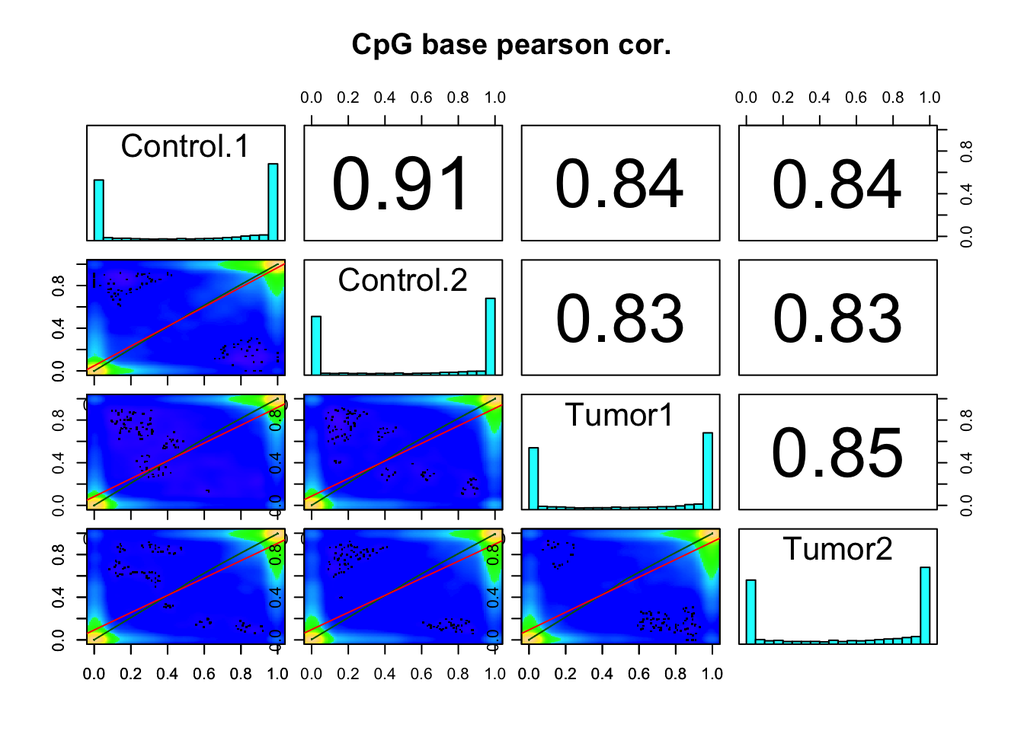

```r
getCorrelation(meth,plot=TRUE)
```

We can also cluster the samples as a first sanity check:

```
## The "ward" method has been renamed to "ward.D"; note new "ward.D2"
```

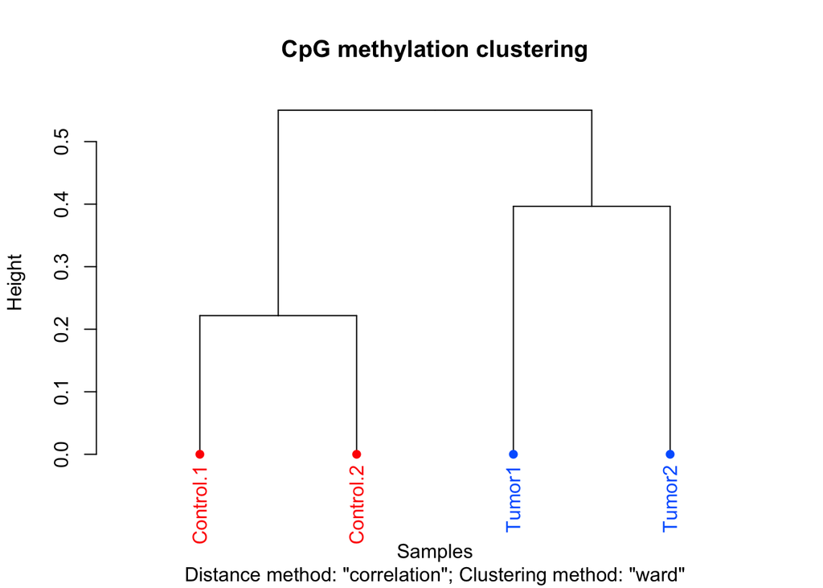

```
##
## Call:
## hclust(d = d, method = HCLUST.METHODS[hclust.method])
##
## Cluster method   : ward.D
## Distance         : pearson
## Number of objects: 4
```

```r
clusterSamples(meth, dist="correlation", method="ward", plot=TRUE)
```

Or we use Principal Component Analysis

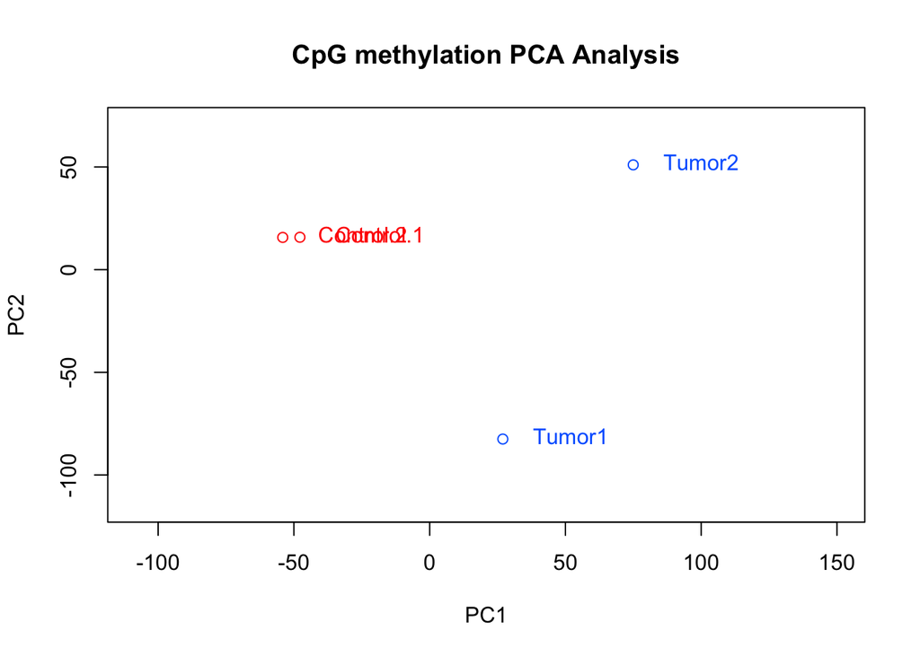

```r
PCASamples(meth,adj.lim=c(1,0.4))
```

As you can see, the Control samples cluster together nicely. However, not surprisingly, there is quite some difference between the tumor samples.

The next thing you might want to do is examine and remove batch effects. Have a look at the methylKit documentation for more details.

Here we will continue to examine the methylation levels across the different samples:

```r
mat=percMethylation(meth)
head(mat)
```

```
##   Control.1 Control.2    Tumor1    Tumor2
## 1  97.22222       100 100.00000 100.00000
## 2 100.00000       100 100.00000 100.00000
## 3 100.00000       100 100.00000  83.33333
## 4 100.00000       100 100.00000 100.00000
## 5  85.33333       100  92.37288  96.70330
## 6 100.00000       100 100.00000  89.01099
```

In order to look at violin plots of the methylation levels for the different samples we will create a new data frame:

```r
m = as.vector(mat)
s =  c(rep(sample.ids[[1]],nrow(meth)),rep(sample.ids[[2]],nrow(meth)),
    rep(sample.ids[[3]],nrow(meth)),rep(sample.ids[[4]],nrow(meth)))

c = c(rep('Ctr',2*nrow(meth)),
    rep('Tu',2*nrow(meth)  ))
DD = data.frame(mCpG=m,sample=as.factor(s),condition=as.factor(c))
```

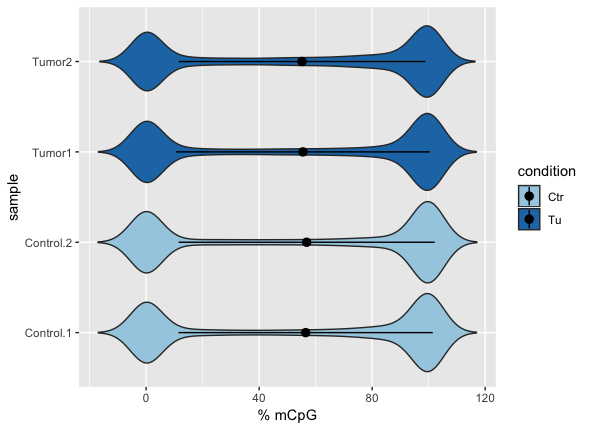

```r
data_summary <- function(x) {
   m <- mean(x)
   ymin <- m-sd(x)
   ymax <- m+sd(x)
   return(c(y=m,ymin=ymin,ymax=ymax))
}

p <- ggplot(DD, aes(x=sample, y=mCpG,fill = condition)) +
    geom_violin(trim=FALSE) +
    scale_fill_manual(values=c( "#a6cee3","#1f78b4","#b2df8a","#33a02c"))+
    coord_flip()+
    labs(x="sample", y = "% mCpG")+
    stat_summary(fun.data=data_summary)
    geom_boxplot(width=0.1)

    plot(p)
```

### Differential Analysis of methylated CpGs

We next try to find CpGs which are significantly different between conditions:

```r
myDiff=calculateDiffMeth(meth)
```

```
## two groups detected:
##  will calculate methylation difference as the difference of
## treatment (group: 1) - control (group: 0)
```

Let’s have a look at the results:

```r
head(myDiff)
```

```
##     chr   start     end strand      pvalue      qvalue meth.diff
## 1 chr11 3148861 3148861      * 0.313697659 0.284625447  1.639344
## 2 chr11 3149957 3149957      * 1.000000000 0.498831247  0.000000
## 3 chr11 3149968 3149968      * 0.056749776 0.066698908 -8.823529
## 4 chr11 3150593 3150593      * 1.000000000 0.498831247  0.000000
## 5 chr11 3150601 3150601      * 0.171194749 0.172300053  4.258373
## 6 chr11 3150641 3150641      * 0.003312862 0.005850224 -4.784689
```

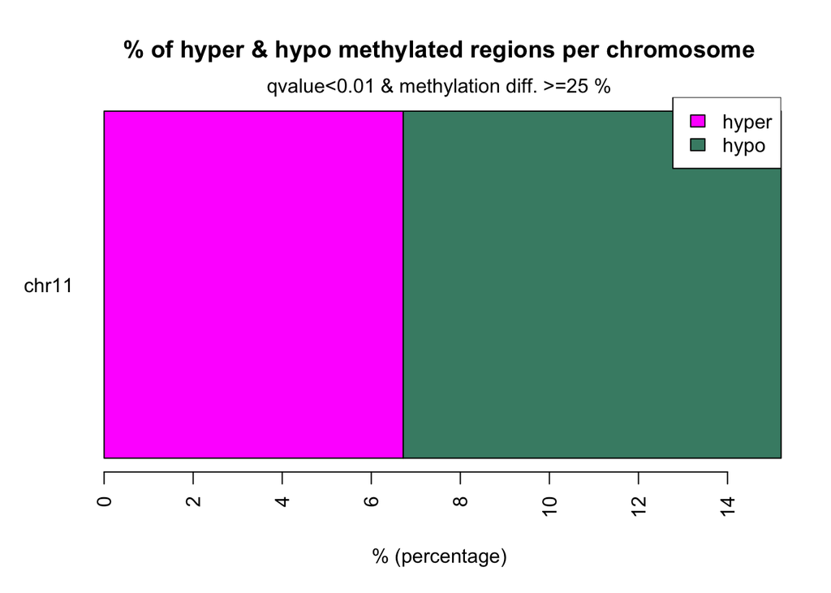

```r
# get hyper methylated bases
myDiff25p.hyper=getMethylDiff(myDiff,difference=25,qvalue=0.01,type="hyper")
#
# get hypo methylated bases
myDiff25p.hypo=getMethylDiff(myDiff,difference=25,qvalue=0.01,type="hypo")
#
#
# get all differentially methylated bases
myDiff25p=getMethylDiff(myDiff,difference=25,qvalue=0.01)
diffMethPerChr(myDiff,plot=TRUE,qvalue.cutoff=0.01, meth.cutoff=25)
```

### Annotating Differentially methylated bases

First we need to get the genomic annotation and turn it into a GRangesList object

```r
txdb = TxDb.Mmusculus.UCSC.mm10.knownGene
seqlevels(txdb) <- "chr11"


exons <- unlist(exonsBy(txdb))
names(exons) <- NULL
type='exons'
mcols(exons) = type

introns <- unlist(intronsByTranscript(txdb))
names(introns) <- NULL
type='intron'
mcols(introns) = type

promoters <- promoters(txdb)
names(promoters) <- NULL
type='promoters'
mcols(promoters) = type

TSSes <- promoters(txdb,upstream=1, downstream=1)
names(TSSes) <- NULL
type='TSSes'
mcols(TSSes) = type

Anno <- GRangesList()
Anno$exons <- exons
Anno$introns <- introns
Anno$promoters <- promoters
Anno$TSSes <- TSSes
```

```r
diffAnnhyper=annotateWithGeneParts(as(myDiff25p.hyper,"GRanges"),Anno)
genomation::getTargetAnnotationStats(diffAnnhyper,percentage=TRUE,precedence=TRUE)
```

```
##   promoter       exon     intron intergenic
##      20.76      14.92      40.41      23.91
```

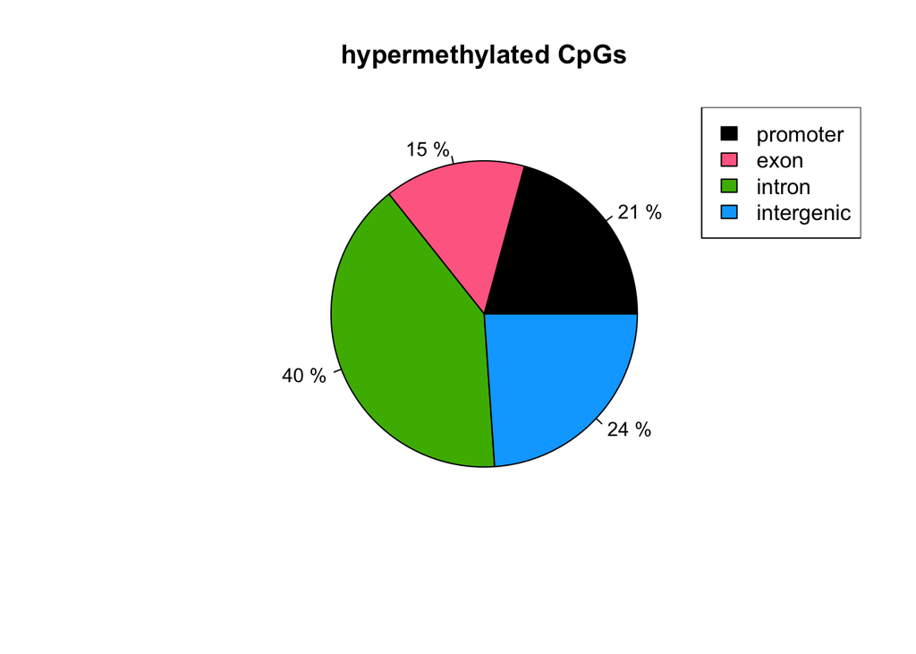

```r
plotTargetAnnotation(diffAnnhyper,precedence=TRUE,
    main="hypermethylated CpGs")
```

```r
diffAnnhypo=annotateWithGeneParts(as(myDiff25p.hypo,"GRanges"),Anno)
genomation::getTargetAnnotationStats(diffAnnhypo,percentage=TRUE,precedence=TRUE)
```

```
##   promoter       exon     intron intergenic
##      10.47      11.66      39.00      38.87
```

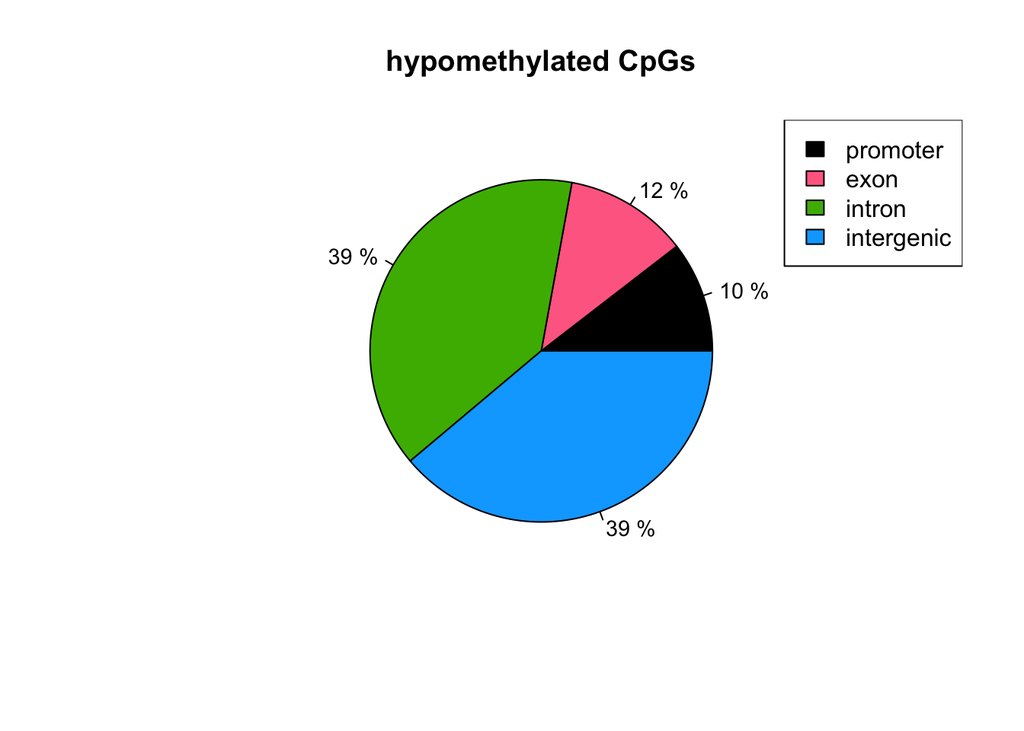

```r
plotTargetAnnotation(diffAnnhypo,precedence=TRUE,
    main="hypomethylated CpGs")
```

```r
annots = c('mm10_cpgs')
annotations = build_annotations(genome = 'mm10', annotations = annots)
diffCpGann=annotateWithFeatureFlank(as(myDiff25p,"GRanges"),
                                    cpg.obj$CpGi,cpg.obj$shores,
                         feature.name="CpGi",flank.name="shores")
plotTargetAnnotation(diffCpGann,col=c("green","gray","white"),
       main="differential methylation annotation")
```

Interesstingly, we find that CpGs in Promoter Regions are more likely to gain methylation in the tumor samples, and that CpGs in intergenic regions are more likely to loose methylation.

In addition to an analysis of individual CpGs, methylKit also allows to follow a tiling window approach. See the Vignette for more details.

## Finding Differentially methylated Regions using BSSeq

### Loading Reads into R

We use the same data as above:

```r
path = 'Data/RRBS/'

dat1.1 <- read.table(file.path(path, "chr11.RRBS_B372.cov.mod2"), header=TRUE, col.names=c("chr","pos", "N", "X"))
dat1.2 <- read.table(file.path(path, "chr11.RRBS_B436.cov.mod2"), header=TRUE, col.names=c("chr","pos", "N", "X"))
dat2.1 <- read.table(file.path(path, "chr11.RRBS_B098.cov.mod2"), header=TRUE, col.names=c("chr","pos", "N", "X"))
dat2.2 <- read.table(file.path(path, "chr11.RRBS_B371.cov.mod2"), header=TRUE, col.names=c("chr","pos", "N", "X"))

sample.ids = list("Control.1", "Control.2","Tumor1","Tumor2")
treatment = c(0,0,1,1)

Type <- c("control", "control","tumor","tumor")
names(Type) <- sample.ids

BS.cancer.ex <- makeBSseqData( list(dat1.1, dat1.2,
                            dat2.1, dat2.2),
                       sampleNames =  sample.ids)

pData(BS.cancer.ex) <- data.frame(Type= Type)
```

Let’s have a quick look at the data:

```r
BS.cancer.ex
```

```
## An object of type 'BSseq' with
##   210936 methylation loci
##   4 samples
## has not been smoothed
## All assays are in-memory
```

And to retrieve some more information about the experimental phenotypes:

```r
pData(BS.cancer.ex)
```

```
## DataFrame with 4 rows and 1 column
##               Type
##           <factor>
## Control.1  control
## Control.2  control
## Tumor1       tumor
## Tumor2       tumor
```

```r
cols <- c('#fc8d59','#91cf60')
names(cols) <- c("tumor","control")
```

### Initial Analysis

Let’s subset the data even further to only look at chromsome 11:

```r
BS.cancer.ex <- chrSelectBSseq(BS.cancer.ex, seqnames = "chr11", order = TRUE)
```

How many sites are we looking at now?

```r
length(BS.cancer.ex)
```

```
## [1] 210936
```

Let’s have a look at the first 10 genomic positions:

```r
head(granges(BS.cancer.ex), n = 10)
```

```
## GRanges object with 10 ranges and 0 metadata columns:
##        seqnames    ranges strand
##           <Rle> <IRanges>  <Rle>
##    [1]    chr11   3101784      *
##    [2]    chr11   3101793      *
##    [3]    chr11   3101800      *
##    [4]    chr11   3101810      *
##    [5]    chr11   3102205      *
##    [6]    chr11   3102221      *
##    [7]    chr11   3104155      *
##    [8]    chr11   3104662      *
##    [9]    chr11   3104734      *
##   [10]    chr11   3105932      *
##   -------
##   seqinfo: 1 sequence from an unspecified genome; no seqlengths
```

What is the read coverage at these positions ?

```r
BS.cov <- getCoverage(BS.cancer.ex)
head(BS.cov, n = 10)
```

```
##       Control.1 Control.2 Tumor1 Tumor2
##  [1,]         0         0      8      0
##  [2,]         0         0      8      0
##  [3,]         0         0      8      0
##  [4,]         0         0      8      0
##  [5,]         0         0      0      4
##  [6,]         0         0      0      4
##  [7,]         0         0      1      0
##  [8,]         0         0      0      1
##  [9,]         0         0      0      5
## [10,]         0         0     13      0
```

And the methylation level ?

```r
BS.met <- getMeth(BS.cancer.ex,  type = "raw")
head(BS.met, n = 10)
```

```
##       Control.1 Control.2 Tumor1 Tumor2
##  [1,]       NaN       NaN  0.000    NaN
##  [2,]       NaN       NaN  0.000    NaN
##  [3,]       NaN       NaN  0.125    NaN
##  [4,]       NaN       NaN  0.000    NaN
##  [5,]       NaN       NaN    NaN      0
##  [6,]       NaN       NaN    NaN      0
##  [7,]       NaN       NaN  0.000    NaN
##  [8,]       NaN       NaN    NaN      1
##  [9,]       NaN       NaN    NaN      0
## [10,]       NaN       NaN  1.000    NaN
```

We could also be interessted in the coverage / methylation level of all CpGs within a certain region, say for a 2800bp region on Chromosome 11 from 3191001 to 3193800:

```r
Reg <- GRanges(seqname='chr11',IRanges( 3191001,3193800))
getCoverage(BS.cancer.ex,regions=Reg)
```

```
## [[1]]
##       [,1] [,2] [,3] [,4]
##  [1,]    5    0    0    0
##  [2,]    0    9    0    0
##  [3,]    0    9    0    0
##  [4,]    9    0   11    0
##  [5,]    9    0   11    0
##  [6,]    9    0   11    0
##  [7,]    9    0   11    0
##  [8,]    9    0   11    0
##  [9,]    8    0    0    0
## [10,]    3    9   18   25
## [11,]    3    9   18   25
## [12,]    3    9   18   25
## [13,]  576  389  732 1049
```

[output cut: 44 more lines]

```r
getMeth(BS.cancer.ex,  type = "raw",regions=Reg)
```

```
## [[1]]
##             [,1]        [,2]       [,3]       [,4]
##  [1,] 0.00000000         NaN        NaN        NaN
##  [2,]        NaN 0.000000000        NaN        NaN
##  [3,]        NaN 0.000000000        NaN        NaN
##  [4,] 1.00000000         NaN 0.00000000        NaN
##  [5,] 1.00000000         NaN 0.09090909        NaN
##  [6,] 0.00000000         NaN 0.00000000        NaN
##  [7,] 0.00000000         NaN 0.00000000        NaN
##  [8,] 0.00000000         NaN 0.00000000        NaN
##  [9,] 0.00000000         NaN        NaN        NaN
## [10,] 1.00000000 1.000000000 1.00000000 1.00000000
## [11,] 0.00000000 1.000000000 0.77777778 0.32000000
## [12,] 0.00000000 1.000000000 0.77777778 0.32000000
## [13,] 0.15277778 0.028277635 0.03551913 0.04385129
```

[output cut: 44 more lines]

Why are there so many NANs in the methylation calls?

Let’s have a look at the coverage: Globally, how many methylation calls do we have ?

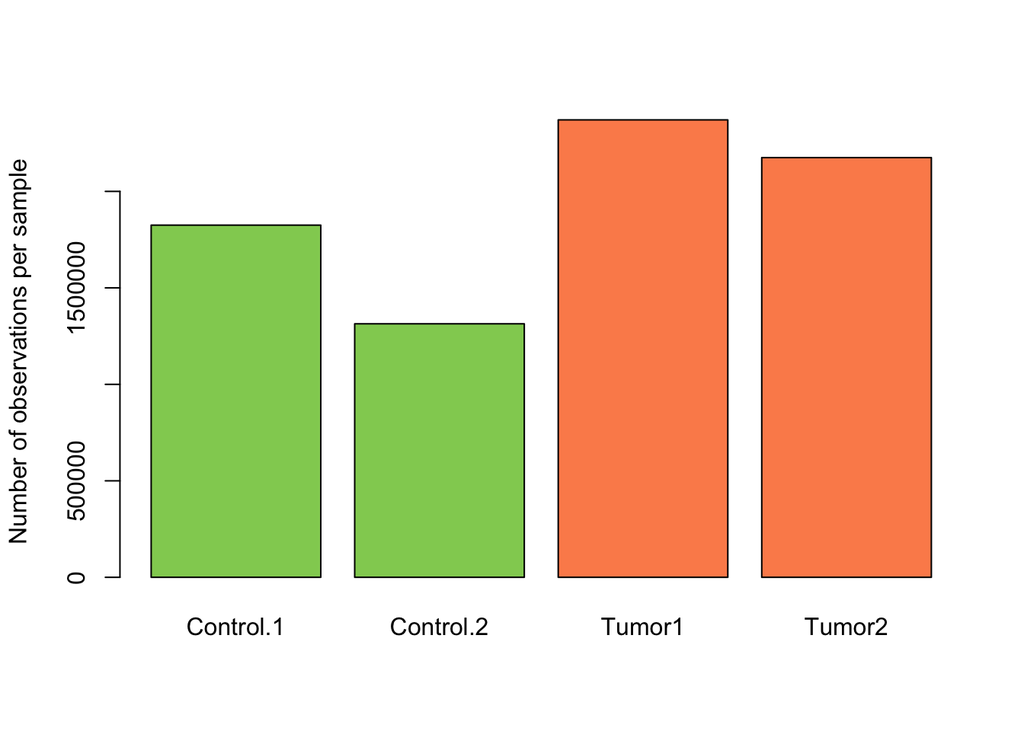

```r
coverage.per.sample <- colSums(BS.cov)
barplot( coverage.per.sample, ylab="Number of observations per sample", names= rownames(attr( BS.cancer.ex ,"colData")),col=cols[match(BS.cancer.ex$Type,names(cols))])
```

What is the number / percentage of CpGs with 0 coverage in all samples ?

```r
sum(rowSums(BS.cov) == 0)
```

```
## [1] 0
```

Coverage per CpG

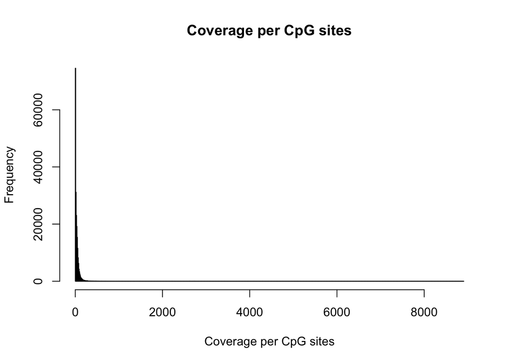

```r
hist( rowSums(BS.cov), breaks=1000, xlab="Coverage per CpG sites", main= "Coverage per CpG sites")
```

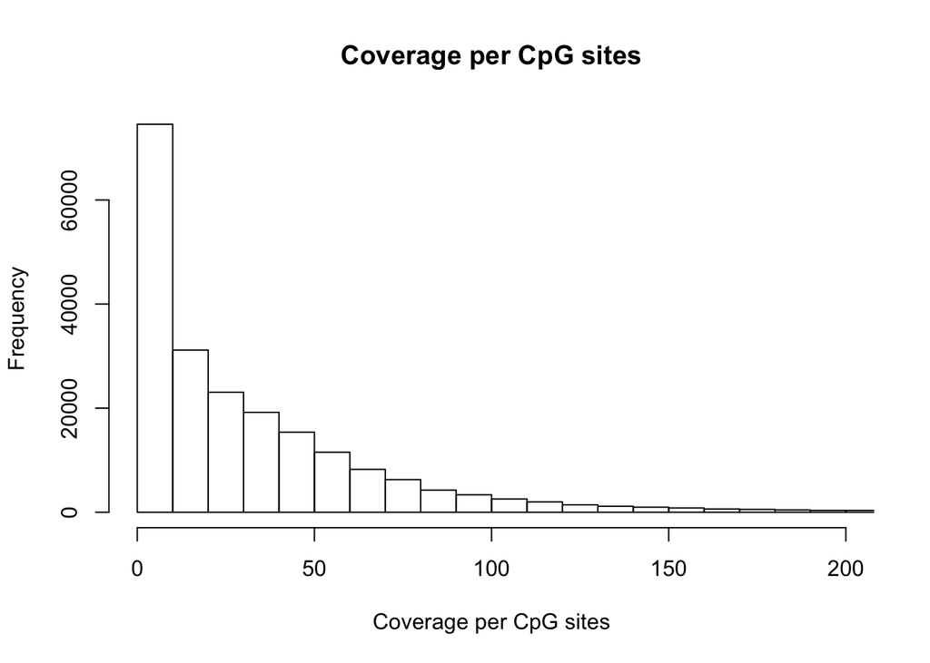

```r
hist( rowSums(BS.cov), breaks=1000, xlab="Coverage per CpG sites", main= "Coverage per CpG sites", xlim=c(0,200))
```

```r
sum(rowSums( BS.cov >= 10) == 4)
```

```
## [1] 19209
```

```r
round(sum(rowSums( BS.cov >= 1) == 4) / length(BS.cancer.ex)*100,2)
```

```
## [1] 36.43
```

## BSmooth: Fitting over region

Applies local averaging to improve precision of regional methylation measurements / minimize coverage issues It can take a some minutes

```r
BS.cancer.ex.fit <- BSmooth(BS.cancer.ex,verbose = TRUE)
```

### Filtering loci per coverage

```r
keepLoci.ex <- which(rowSums(BS.cov[, BS.cancer.ex$Type == "tumor"] >= 2) >= 2 &
                       rowSums(BS.cov[, BS.cancer.ex$Type == "control"] >= 2) >= 2)


length(keepLoci.ex)
```

```
## [1] 66383
```

```r
BS.cancer.ex.fit <- BS.cancer.ex.fit[keepLoci.ex,]

#####
BS.cancer.ex.tstat <- BSmooth.tstat(BS.cancer.ex.fit,
                                    group1 = c("Tumor1","Tumor2"),
                                    group2 = c("Control.1", "Control.2"),
                                    estimate.var = "group2",
                                    local.correct = TRUE,
                                    verbose = TRUE)
```

```
## [BSmooth.tstat] preprocessing ... done in 0.2 sec
## [BSmooth.tstat] computing stats within groups ... done in 0.0 sec
## [BSmooth.tstat] computing stats across groups ... done in 1.1 sec
```

## Finding DMRs

```r
dmrs0 <- dmrFinder(BS.cancer.ex.tstat, cutoff = c(-4.6, 4.6))
```

```
## [dmrFinder] creating dmr data.frame
```

```r
dmrs <- subset(dmrs0, n >= 3 & abs(meanDiff) >= 0.1)
head(dmrs)
```

```
##       chr    start      end idxStart idxEnd cluster   n width invdensity
## 114 chr11 82930464 82932037    33615  33764    6196 150  1574  10.493333
## 115 chr11 82932521 82933357    33765  33821    6197  57   837  14.684211
## 98  chr11 66525886 66526886    21394  21460    4172  67  1001  14.940299
## 99  chr11 67455427 67455736    21703  21751    4240  49   310   6.326531
## 103 chr11 69559967 69560379    23527  23563    4569  37   413  11.162162
## 78  chr11  4745997  4746366     1230   1264     218  35   370  10.571429
##       areaStat   maxStat   meanDiff group1.mean group2.mean   tstat.sd
## 114 -1305.4457 -4.827954 -0.6736451   0.1737162   0.8473614 0.07284007
## 115  -588.8385 -9.606609 -0.7753301   0.2032949   0.9786251 0.07008583
## 98   -535.3952 -4.777467 -0.5656166   0.3704854   0.9361020 0.07066659
## 99   -281.3411 -4.600059 -0.4247835   0.5387665   0.9635500 0.06201177
## 103  -244.2169 -5.732185 -0.4856206   0.3732968   0.8589174 0.07042821
## 78   -225.7915 -5.361329 -0.3474851   0.5727045   0.9201896 0.06854483
##     direction
## 114      hypo
## 115      hypo
## 98       hypo
## 99       hypo
## 103      hypo
## 78       hypo
```

### Number of DMRs

```r
nrow(dmrs)
```

```
## [1] 68
```

### Size of the DMRs

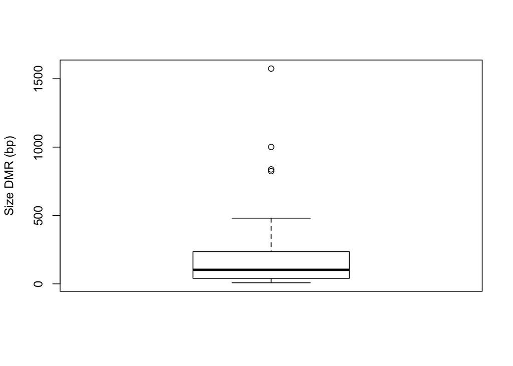

```r
boxplot( dmrs$width, ylab="Size DMR (bp)")
```

### Number of hypomethylated and methylated DMRs

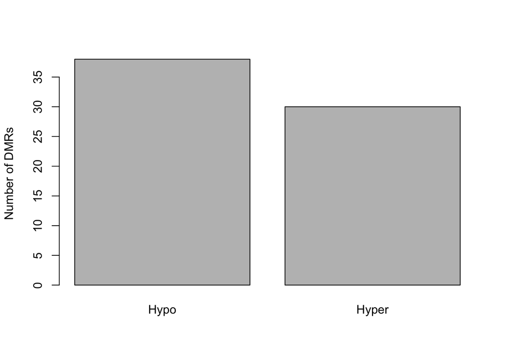

```r
barplot( c(sum(dmrs$direction == "hypo"), sum(dmrs$direction == "hyper")), ylab="Number of DMRs",
         names=c("Hypo", "Hyper"))
```

### Plot example DRMs

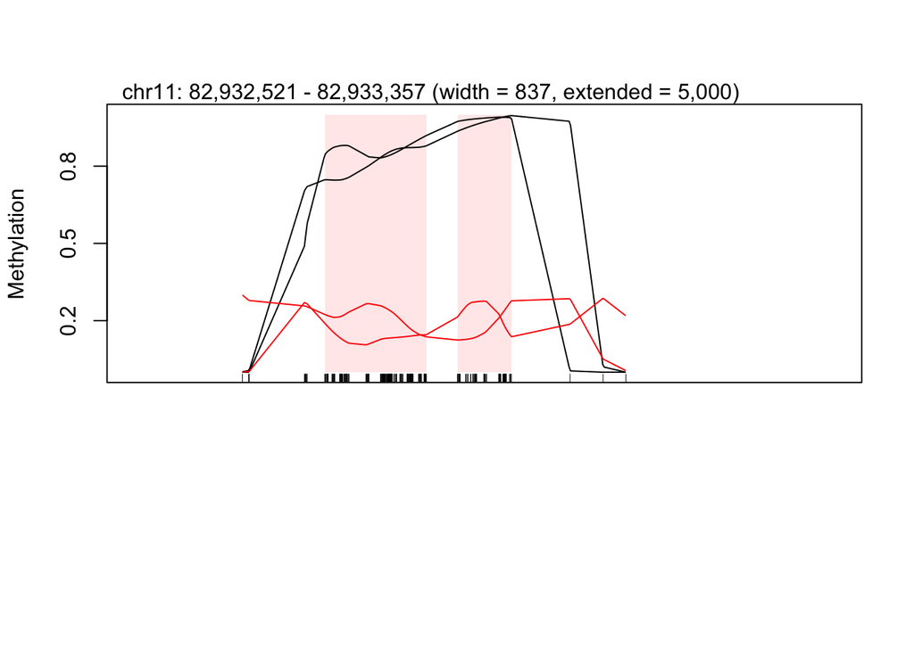

```r
plotRegion(BS.cancer.ex.fit, dmrs[2,], extend = 5000, addRegions = dmrs, col=c(rep("black",2), rep("red", 2)))
```

```r
Reg <- GRanges(seqname=dmrs[2,1],IRanges( dmrs[2,2],dmrs[2,3]))
```